# Marketing Analytics Report

Cluserng Analysis for Store attributes

```r
library(magrittr )
library(tidyverse)
library(flexclust)
```

Load the libraries

# Question-1) Read and inspect the data set. Provide a descriptive analysis for each of the variables in the data set.

```r
office<- read.csv("office.csv")
summary(office)
```

```
 respondent_id    variety_of_choice  electronics      furniture
 Min.   :  1.00   Min.   : 4.000    Min.   : 1.00   Min.   :0.00
 1st Qu.: 50.75   1st Qu.: 6.000    1st Qu.: 3.00   1st Qu.:1.00
 Median :100.50   Median : 8.000    Median : 4.50   Median :2.00
 Mean   :100.50   Mean   : 7.565    Mean   : 4.45   Mean   :3.27
 3rd Qu.:150.25   3rd Qu.:10.000    3rd Qu.: 6.00   3rd Qu.:6.00
 Max.   :200.00   Max.   :10.000    Max.   :10.00   Max.   :7.00
 quality_of_service   low_prices     return_policy   professional
 Min.   :1.00       Min.   : 1.000   Min.   : 1.00   Length:200
 1st Qu.:2.00       1st Qu.: 2.000   1st Qu.: 3.00   Class :character
 Median :3.00       Median : 5.000   Median : 4.00   Mode  :character
 Mean   :3.53       Mean   : 4.795   Mean   : 4.25
 3rd Qu.:4.00       3rd Qu.: 7.000   3rd Qu.: 6.00
 Max.   :9.00       Max.   :10.000   Max.   :10.00
     income           age
 Min.   :13.00   Min.   :21.00
 1st Qu.:15.00   1st Qu.:24.00
 Median :19.50   Median :27.00
 Mean   :32.17   Mean   :32.52
 3rd Qu.:54.25   3rd Qu.:38.00
 Max.   :95.00   Max.   :68.00
```

```r
glimpse(office)
```

```
Rows: 200
Columns: 10
$ respondent_id      <int> 1, 2, 3, 4, 5, 6, 7, 8, 9, 10, 11, 12, 13, 14, 15, ~
$ variety_of_choice  <int> 8, 6, 6, 8, 4, 8, 7, 7, 10, 8, 9, 4, 10, 6, 7, 9, 1~
$ electronics        <int> 3, 3, 1, 3, 6, 4, 2, 5, 7, 4, 8, 4, 3, 5, 3, 1, 1, ~
$ furniture          <int> 6, 1, 2, 3, 3, 3, 2, 3, 5, 0, 2, 2, 6, 2, 0, 7, 7, ~
$ quality_of_service <int> 3, 4, 4, 4, 4, 5, 2, 2, 1, 4, 1, 8, 1, 4, 2, 4, 4, ~
$ low_prices         <int> 2, 7, 9, 8, 2, 10, 8, 2, 5, 9, 5, 2, 3, 3, 7, 5, 4,~
$ return_policy      <int> 2, 1, 6, 7, 5, 6, 7, 3, 4, 1, 2, 3, 3, 6, 6, 2, 3, ~
$ professional       <chr> "non-professional", "non-professional", "non-profes~
$ income             <int> 16, 22, 18, 18, 35, 13, 22, 19, 14, 16, 82, 78, 17,~
$ age                <int> 28, 27, 22, 29, 51, 24, 27, 26, 27, 28, 34, 49, 22,~
```

This databse contains data of the 200 respondents and their choice of preferences when it comes to buy the office is equipment

# Question-2) Make a new data object (e.g., a data.frame or tibble) for clustering that includes only the attitudinal variables from the original data set. Then normalise (use z-score standardisation) all variables in this new data object. Which variable has the smallest minimum value and which variable has the largest maximum value in the normalized data set?

```r
office_normalized<- scale(office[, c(
                           "variety_of_choice",
                           "electronics",
                           "furniture",
                           "quality_of_service",
                           "low_prices",
                           "return_policy"
                           )]) %>%
  as_tibble()
```

```r
summary(office_normalized)
```

```
 variety_of_choice  electronics         furniture       quality_of_service
 Min.   :-1.7723   Min.   :-1.77534   Min.   :-1.3775   Min.   :-1.0922
 1st Qu.:-0.7780   1st Qu.:-0.74616   1st Qu.:-0.9562   1st Qu.:-0.6605
 Median : 0.2163   Median : 0.02573   Median :-0.5350   Median :-0.2288
 Mean   : 0.0000   Mean   : 0.00000   Mean   : 0.0000   Mean   : 0.0000
 3rd Qu.: 1.2106   3rd Qu.: 0.79762   3rd Qu.: 1.1500   3rd Qu.: 0.2029
 Max.   : 1.2106   Max.   : 2.85598   Max.   : 1.5713   Max.   : 2.3614
   low_prices      return_policy
 Min.   :-1.4995   Min.   :-1.5861
 1st Qu.:-1.1044   1st Qu.:-0.6100
 Median : 0.0810   Median :-0.1220
 Mean   : 0.0000   Mean   : 0.0000
 3rd Qu.: 0.8713   3rd Qu.: 0.8541
 Max.   : 2.0567   Max.   : 2.8062
```

Mean of the normalized attributes is zero always Electronics attribute has the maximum and minimum value

# Question-3) Run the hierarchical clustering algorithm using method = “ward.D2” on the normalised data and use set.seed(123)for reproducibility. Plot the dendogram.

Now let’s compute the distances between data points (using euclidean distance)

```r
distances <- dist(office_normalized,
                  method = "euclidean")

as.matrix(distances)[1:5, 1:5]
```

```
         1        2        3        4        5
1 0.000000 3.122933 4.066279 3.654938 3.203876
2 3.122933 0.000000 2.795657 3.229408 3.434497
3 4.066279 2.795657 0.000000 1.618520 3.959120
4 3.654938 3.229408 1.618520 0.000000 3.593200
5 3.203876 3.434497 3.959120 3.593200 0.000000
```

```r
hier_clust <- hclust(distances, method = "ward.D2")
```

plot the dendogram of the hierarchical clustering process

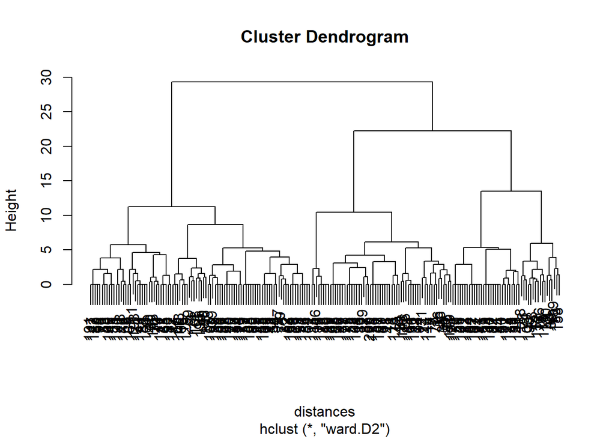

```r
plot(hier_clust)
```

The office chooses to use 6 clusters after seeing the dendrogram and consulting with marketing. Using cutree, split the data into 6 clusters.

# Question-4) The office chooses to use 6 clusters after seeing the dendrogram and consulting with marketing. Using cutree, split the data into 6 clusters.

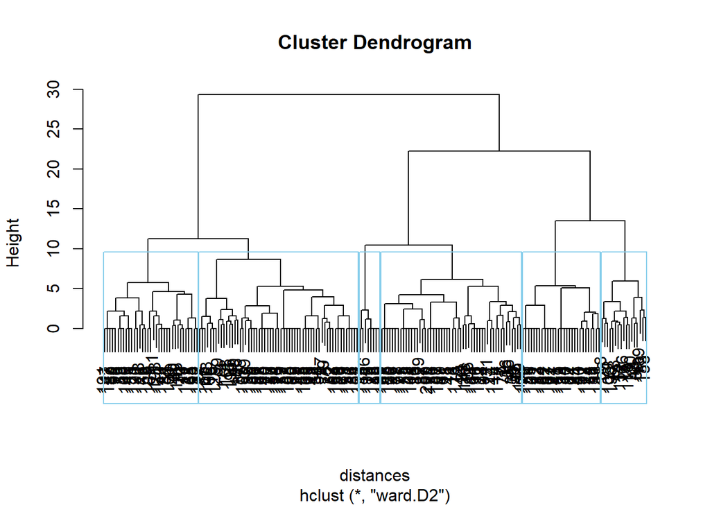

```r
plot(hier_clust)
rect.hclust(hier_clust, k = 6, border = "skyblue")
```

```r
hiercut_obs <- cutree(hier_clust, k = 6)
table(hiercut_obs)
```

```
hiercut_obs
 1  2  3  4  5  6
59  8 52 17 35 29
```

Plotted dendogram and split into 6 clusters using cuttree